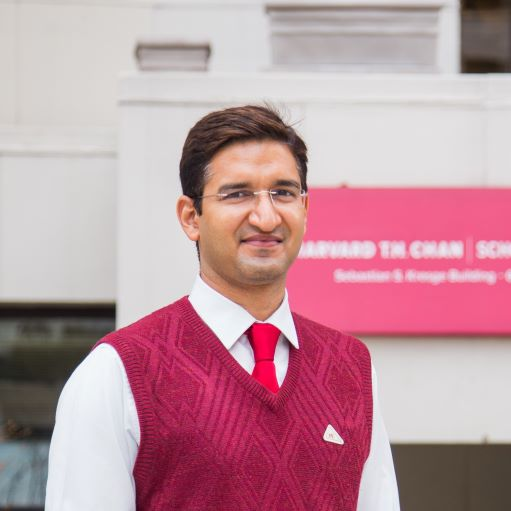

# Aditya Dahiya

Greetings, I’m Aditya Dahiya. By day, I wrangle bureaucracy, but by night, I’m the data wizard conjuring up visual delights and diving deep into health data science. This website is my gallery of creations. So, channel your inner Sherlock and embark on an adventure of discovery! Here are some of my works:

1. My [**Data Visualizations**](https://aditya-dahiya.github.io/projects_presentations/data_vizs.html), [**Projects**](https://aditya-dahiya.github.io/projects_presentations/projects.html) and [**Presentations**](https://aditya-dahiya.github.io/projects_presentations/presentations.html).
2. [**FaNoOp**](https://aditya-dahiya.github.io/FaNoOp/) (**Facts! Not Opinions!**) - my un-opinionated blog on insights from publicly available data.
3. The [**visage**](https://aditya-dahiya.github.io/visage/): *Visualizing Information and Spatial Analysis with ggplot2 Extensions* - a website with Code and techniques.
4. Academic books’ solutions that I have attempted: –
   - [**Solutions Manual**](https://aditya-dahiya.github.io/ggplot2book3e/) **(and much more!)** for the [third edition](https://ggplot2-book.org/) of *ggplot2: Elegant Graphics for Data Analysis (3e)* by [Hadley Wickham](https://hadley.nz/), [Danielle Navarro](https://djnavarro.net/), and [Thomas Lin Pedersen](https://www.data-imaginist.com/).
   - [**Solutions Manual**](https://aditya-dahiya.github.io/RfDS2solutions/) of the book *R for Data Science (2nd Edition)* by [Hadley Wickham](https://hadley.nz/), [Mine Çetinkaya-Rundel](https://mine-cr.com/), [Garrett Grolemund](https://www.rstudio.com/authors/garrett-grolemund/).
   - [**Solutions**](https://aditya-dahiya.github.io/ISLR1solutions/) for the Book *An Introduction to Statistical Learning: With Applications in R, 1<sup>st</sup> edition* by [Daniela Witten](https://www.danielawitten.com/), [Gareth M. James](https://www.garethmjames.com/), [Trevor Hastie](https://hastie.su.domains/), [Robert Tibshirani](https://tibshirani.su.domains/).